# Analyzing and Predicting Regional Sales

### Introduction

The regional sales dataset includes 15 features describing product details and sales metrics. It also provides a comprehensive overview of sales channels, transactions and customer interactions.

1. Import Data and Packages
2. Data Validation
3. Data Exploration
4. Machine Learning Methodologies

## 1. Import Data and Packages

```python
import pandas as pd
import seaborn as sns
import matplotlib.pyplot as plt
import numpy as np

# Read in `road-accidents.csv`
df= pd.read_csv('US_Regional_Sales_Data.csv')

# Save the number of rows columns as a tuple
rows_and_cols = df.shape
print('There are {} rows and {} columns.\n'.format(
    rows_and_cols[0], rows_and_cols[1]))

# Generate an overview of the DataFrame
df_info = df.info()
print(df_info)

# Display the last five rows of the DataFrame
df.head()
```

```
There are 7991 rows and 16 columns.

<class 'pandas.core.frame.DataFrame'>
RangeIndex: 7991 entries, 0 to 7990
Data columns (total 16 columns):
 #   Column            Non-Null Count  Dtype
---  ------            --------------  -----
 0   OrderNumber       7991 non-null   object
 1   Sales Channel     7991 non-null   object
 2   WarehouseCode     7991 non-null   object
 3   ProcuredDate      7991 non-null   object
 4   OrderDate         7991 non-null   object
 5   ShipDate          7991 non-null   object
 6   DeliveryDate      7991 non-null   object
 7   CurrencyCode      7991 non-null   object
 8   _SalesTeamID      7991 non-null   int64
 9   _CustomerID       7991 non-null   int64
 10  _StoreID          7991 non-null   int64
 11  _ProductID        7991 non-null   int64
 12  Order Quantity    7991 non-null   int64
 13  Discount Applied  7991 non-null   float64
 14  Unit Cost         7991 non-null   object
 15  Unit Price        7991 non-null   object
dtypes: float64(1), int64(5), object(10)
memory usage: 999.0+ KB
None
```

|  | OrderNumber | Sales Channel | WarehouseCode | ProcuredDate | OrderDate | ShipDate | DeliveryDate | CurrencyCode | _SalesTeamID | _CustomerID | _StoreID | _ProductID | Order Quantity | Discount Applied | Unit Cost | Unit Price |
| --- | --- | --- | --- | --- | --- | --- | --- | --- | --- | --- | --- | --- | --- | --- | --- | --- |
| 0 | SO - 000101 | In-Store | WARE-UHY1004 | 31/12/17 | 31/5/18 | 14/6/18 | 19/6/18 | USD | 6 | 15 | 259 | 12 | 5 | 0.075 | 1,001.18 | 1,963.10 |
| 1 | SO - 000102 | Online | WARE-NMK1003 | 31/12/17 | 31/5/18 | 22/6/18 | 2/7/18 | USD | 14 | 20 | 196 | 27 | 3 | 0.075 | 3,348.66 | 3,939.60 |
| 2 | SO - 000103 | Distributor | WARE-UHY1004 | 31/12/17 | 31/5/18 | 21/6/18 | 1/7/18 | USD | 21 | 16 | 213 | 16 | 1 | 0.050 | 781.22 | 1,775.50 |
| 3 | SO - 000104 | Wholesale | WARE-NMK1003 | 31/12/17 | 31/5/18 | 2/6/18 | 7/6/18 | USD | 28 | 48 | 107 | 23 | 8 | 0.075 | 1,464.69 | 2,324.90 |
| 4 | SO - 000105 | Distributor | WARE-NMK1003 | 10/4/18 | 31/5/18 | 16/6/18 | 26/6/18 | USD | 22 | 49 | 111 | 26 | 8 | 0.100 | 1,476.14 | 1,822.40 |

## 2. Data Validation

```python
#null values
missing= df.isna().sum() # no null
print(missing)

#duplicated values
print(df.duplicated().unique())

print(df.nunique()) # of unqiue values

print(df.shape[0]) # of rows
```

```
OrderNumber         0
Sales Channel       0
WarehouseCode       0
ProcuredDate        0
OrderDate           0
ShipDate            0
DeliveryDate        0
CurrencyCode        0
_SalesTeamID        0
_CustomerID         0
_StoreID            0
_ProductID          0
Order Quantity      0
Discount Applied    0
Unit Cost           0
Unit Price          0
dtype: int64
[False]
OrderNumber         7991
Sales Channel          4
WarehouseCode          6
ProcuredDate          11
OrderDate            945
ShipDate             966
DeliveryDate         966
CurrencyCode           1
_SalesTeamID          28
_CustomerID           50
_StoreID             367
_ProductID            47
Order Quantity         8
Discount Applied       7
Unit Cost           5252
Unit Price           664
dtype: int64
7991
```

```python
# drop redundant columns
df.drop(['CurrencyCode', 'OrderNumber'], axis=1, inplace=True)
```

```python
df.dtypes
```

```
Sales Channel        object
WarehouseCode        object
ProcuredDate         object
OrderDate            object
ShipDate             object
DeliveryDate         object
_SalesTeamID          int64
_CustomerID           int64
_StoreID              int64
_ProductID            int64
Order Quantity        int64
Discount Applied    float64
Unit Cost            object
Unit Price           object
dtype: object
```

```python
# convert data types

#Obj to float
df['Unit Cost']=df['Unit Cost'].str.replace(',','')
df['Unit Price']=df['Unit Price'].str.replace(',','')
df.head()

df['Unit Cost']=df['Unit Cost'].astype(float)
df['Unit Price']=df['Unit Price'].astype(float)
```

```python
#float to Date
list= ['ProcuredDate', 'OrderDate', 'ShipDate', 'DeliveryDate']
for x in list:
    df[x]=pd.to_datetime(df[x])
```

```python
#int to string
list=['_SalesTeamID', '_CustomerID', '_StoreID', '_ProductID']
for x in list:
    df[x]=df[x].astype(str)
```

```python
#datatypes
df.dtypes
```

```
Sales Channel               object
WarehouseCode               object
ProcuredDate        datetime64[ns]
OrderDate           datetime64[ns]
ShipDate            datetime64[ns]
DeliveryDate        datetime64[ns]
_SalesTeamID                object
_CustomerID                 object
_StoreID                    object
_ProductID                  object
Order Quantity               int64
Discount Applied           float64
Unit Cost                  float64
Unit Price                 float64
dtype: object
```

```python
print(df.nunique())
print(df['Sales Channel'].unique())
print(df['WarehouseCode'].unique())
```

```
Sales Channel          4
WarehouseCode          6
ProcuredDate          11
OrderDate            945
ShipDate             966
DeliveryDate         966
_SalesTeamID          28
_CustomerID           50
_StoreID             367
_ProductID            47
Order Quantity         8
Discount Applied       7
Unit Cost           5252
Unit Price           664
dtype: int64
['In-Store' 'Online' 'Distributor' 'Wholesale']
['WARE-UHY1004' 'WARE-NMK1003' 'WARE-PUJ1005' 'WARE-XYS1001'
 'WARE-MKL1006' 'WARE-NBV1002']
```

```python
#inpect numerical features
df.describe()
```

|  | Order Quantity | Discount Applied | Unit Cost | Unit Price |
| --- | --- | --- | --- | --- |
| count | 7991.000000 | 7991.000000 | 7991.000000 | 7991.000000 |
| mean | 4.525341 | 0.114394 | 1431.911513 | 2284.536504 |
| std | 2.312631 | 0.085570 | 1112.413063 | 1673.096364 |
| min | 1.000000 | 0.050000 | 68.680000 | 167.500000 |
| 25% | 3.000000 | 0.050000 | 606.120000 | 1031.800000 |
| 50% | 5.000000 | 0.075000 | 1080.580000 | 1849.200000 |
| 75% | 7.000000 | 0.150000 | 2040.250000 | 3611.300000 |
| max | 8.000000 | 0.400000 | 5498.560000 | 6566.000000 |

## Data Exploration

#### Feature Generation

```python
#generate new columns
df['TotalProfit']= (df['Unit Price']- df['Unit Cost']) * df['Order Quantity'] # total_profit
df['TotalSales']= df['Order Quantity']*df['Unit Price'] #TotalSales
df['ord_to_ship']= df['ShipDate'] - df['OrderDate'] # Order to shipping time
df['delivery']=  df['DeliveryDate']-df['OrderDate'] # Delivery time
df['shipping']=  df['DeliveryDate']- df['ShipDate'] # Shipping time
df['shelf_time']=df['OrderDate'] - df['ProcuredDate'] # Shelf Time

df
```

|  | Sales Channel | WarehouseCode | ProcuredDate | OrderDate | ShipDate | DeliveryDate | _SalesTeamID | _CustomerID | _StoreID | _ProductID | Order Quantity | Discount Applied | Unit Cost | Unit Price | TotalProfit | TotalSales | ord_to_ship | delivery | shipping | shelf_time |
| --- | --- | --- | --- | --- | --- | --- | --- | --- | --- | --- | --- | --- | --- | --- | --- | --- | --- | --- | --- | --- |
| 0 | In-Store | WARE-UHY1004 | 2017-12-31 | 2018-05-31 | 2018-06-14 | 2018-06-19 | 6 | 15 | 259 | 12 | 5 | 0.075 | 1001.18 | 1963.1 | 4809.60 | 9815.5 | 14 days | 19 days | 5 days | 151 days |
| 1 | Online | WARE-NMK1003 | 2017-12-31 | 2018-05-31 | 2018-06-22 | 2018-02-07 | 14 | 20 | 196 | 27 | 3 | 0.075 | 3348.66 | 3939.6 | 1772.82 | 11818.8 | 22 days | -113 days | -135 days | 151 days |
| 2 | Distributor | WARE-UHY1004 | 2017-12-31 | 2018-05-31 | 2018-06-21 | 2018-01-07 | 21 | 16 | 213 | 16 | 1 | 0.050 | 781.22 | 1775.5 | 994.28 | 1775.5 | 21 days | -144 days | -165 days | 151 days |
| 3 | Wholesale | WARE-NMK1003 | 2017-12-31 | 2018-05-31 | 2018-02-06 | 2018-07-06 | 28 | 48 | 107 | 23 | 8 | 0.075 | 1464.69 | 2324.9 | 6881.68 | 18599.2 | -114 days | 36 days | 150 days | 151 days |
| 4 | Distributor | WARE-NMK1003 | 2018-10-04 | 2018-05-31 | 2018-06-16 | 2018-06-26 | 22 | 49 | 111 | 26 | 8 | 0.100 | 1476.14 | 1822.4 | 2770.08 | 14579.2 | 16 days | 26 days | 10 days | -126 days |
| ... | ... | ... | ... | ... | ... | ... | ... | ... | ... | ... | ... | ... | ... | ... | ... | ... | ... | ... | ... | ... |
| 7986 | In-Store | WARE-MKL1006 | 2020-09-26 | 2020-12-30 | 2021-07-01 | 2021-01-14 | 9 | 41 | 339 | 29 | 1 | 0.075 | 121.94 | 234.5 | 112.56 | 234.5 | 183 days | 15 days | -168 days | 95 days |
| 7987 | Online | WARE-NMK1003 | 2020-09-26 | 2020-12-30 | 2021-02-01 | 2021-04-01 | 14 | 29 | 202 | 3 | 6 | 0.050 | 1921.56 | 3202.6 | 7686.24 | 19215.6 | 33 days | 92 days | 59 days | 95 days |
| 7988 | Online | WARE-UHY1004 | 2020-09-26 | 2020-12-30 | 2021-01-23 | 2021-01-26 | 14 | 32 | 241 | 35 | 5 | 0.200 | 2792.76 | 3825.7 | 5164.70 | 19128.5 | 24 days | 27 days | 3 days | 95 days |
| 7989 | Online | WARE-NMK1003 | 2020-09-26 | 2020-12-30 | 2021-01-20 | 2021-01-25 | 20 | 42 | 112 | 36 | 8 | 0.100 | 804.00 | 1072.0 | 2144.00 | 8576.0 | 21 days | 26 days | 5 days | 95 days |
| 7990 | In-Store | WARE-UHY1004 | 2020-09-26 | 2020-12-30 | 2021-01-13 | 2021-01-19 | 6 | 41 | 237 | 43 | 5 | 0.075 | 1370.82 | 2211.0 | 4200.90 | 11055.0 | 14 days | 20 days | 6 days | 95 days |

7991 rows × 20 columns

#### Feature Correlation

```python
df.corr()
```

|  | Order Quantity | Discount Applied | Unit Cost | Unit Price | TotalProfit | TotalSales |
| --- | --- | --- | --- | --- | --- | --- |
| Order Quantity | 1.000000 | -0.007733 | 0.001814 | 0.002566 | 0.474976 | 0.527996 |
| Discount Applied | -0.007733 | 1.000000 | 0.012185 | 0.014439 | 0.017907 | 0.013102 |
| Unit Cost | 0.001814 | 0.012185 | 1.000000 | 0.942167 | 0.501627 | 0.716208 |
| Unit Price | 0.002566 | 0.014439 | 0.942167 | 1.000000 | 0.674257 | 0.758778 |
| TotalProfit | 0.474976 | 0.017907 | 0.501627 | 0.674257 | 1.000000 | 0.892276 |
| TotalSales | 0.527996 | 0.013102 | 0.716208 | 0.758778 | 0.892276 | 1.000000 |

```python
# Variables with strong positive correlations
corr=df.corr()
corr[corr > .7]
```

|  | Order Quantity | Discount Applied | Unit Cost | Unit Price | TotalProfit | TotalSales |
| --- | --- | --- | --- | --- | --- | --- |
| Order Quantity | 1.0 | NaN | NaN | NaN | NaN | NaN |
| Discount Applied | NaN | 1.0 | NaN | NaN | NaN | NaN |
| Unit Cost | NaN | NaN | 1.000000 | 0.942167 | NaN | 0.716208 |
| Unit Price | NaN | NaN | 0.942167 | 1.000000 | NaN | 0.758778 |
| TotalProfit | NaN | NaN | NaN | NaN | 1.000000 | 0.892276 |
| TotalSales | NaN | NaN | 0.716208 | 0.758778 | 0.892276 | 1.000000 |

```python
# Variables with strong negative correlations
corr[corr < -.7]
```

|  | Order Quantity | Discount Applied | Unit Cost | Unit Price | TotalProfit | TotalSales |
| --- | --- | --- | --- | --- | --- | --- |
| Order Quantity | NaN | NaN | NaN | NaN | NaN | NaN |
| Discount Applied | NaN | NaN | NaN | NaN | NaN | NaN |
| Unit Cost | NaN | NaN | NaN | NaN | NaN | NaN |
| Unit Price | NaN | NaN | NaN | NaN | NaN | NaN |
| TotalProfit | NaN | NaN | NaN | NaN | NaN | NaN |
| TotalSales | NaN | NaN | NaN | NaN | NaN | NaN |

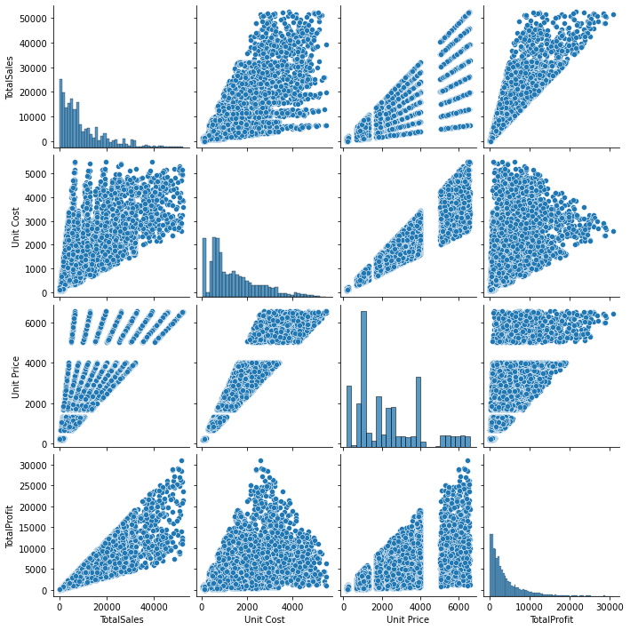

```python
#scatterplots
sns.pairplot(df[['TotalSales', 'Unit Cost', 'Unit Price','TotalProfit']])
plt.show()
```

### Time Series Analysis

```python
#create month and year columns
def extract_month_year(date):
    return pd.Series([date.month, date.year])

# apply function to date column
df[['month', 'year']] = df['OrderDate'].apply(extract_month_year)
```

```python
#3 Highest Total Sales months vs three lowest from 2018-2020
print('Highest:',df.groupby('month')['TotalSales'].sum().sort_values(ascending=False).head(3),'\n',
      'Lowest:', df.groupby('month')['TotalSales'].sum().sort_values().head(3))
```

```
Highest: month
11    8410483.2
12    8214722.6
7     8168211.2
Name: TotalSales, dtype: float64
 Lowest: month
3    5393386.1
2    5455448.2
4    6031440.5
Name: TotalSales, dtype: float64
```

```python
#yearly total sales by month
y_2018= df[df['year']==2018][['month','TotalSales']].groupby('month')['TotalSales'].sum().reset_index()
y_2019= df[df['year']==2019][['month','TotalSales']].groupby('month')['TotalSales'].sum().reset_index()
y_2020= df[df['year']==2020][['month','TotalSales']].groupby('month')['TotalSales'].sum().reset_index()
y_2020.dtypes
```

```
month           int64
TotalSales    float64
dtype: object
```

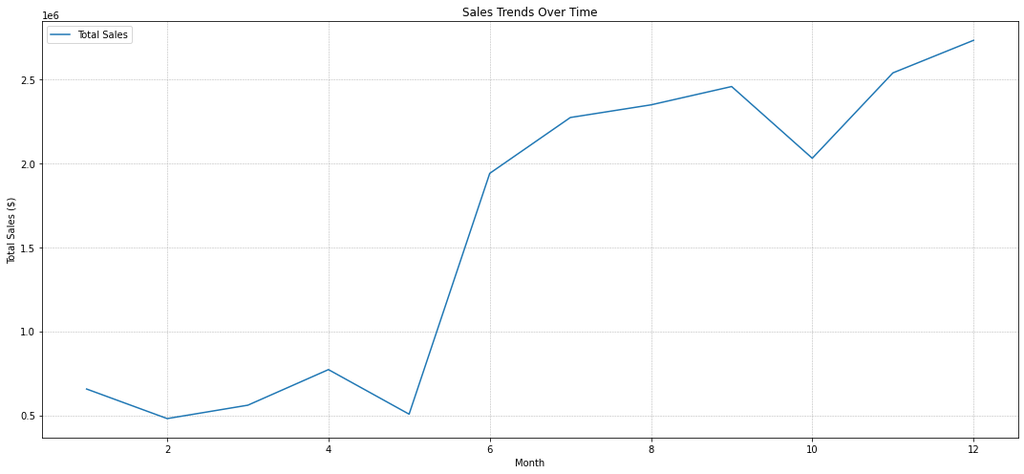

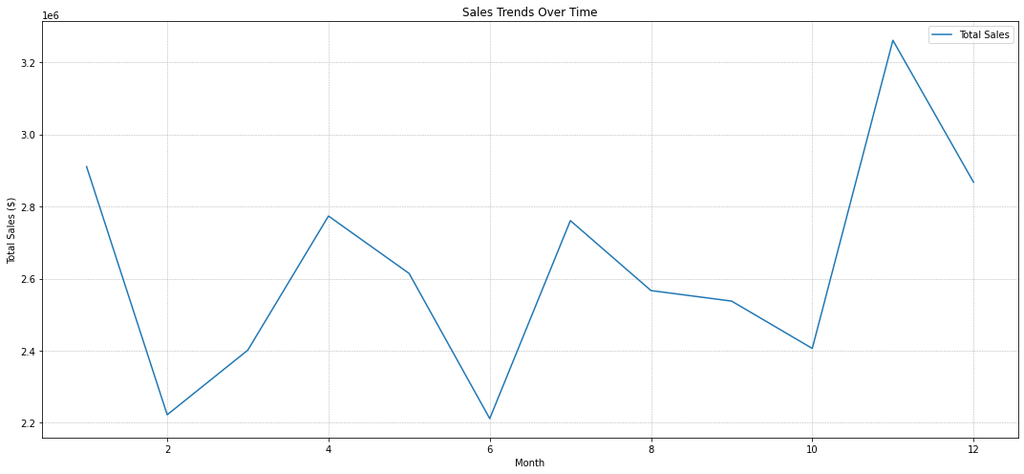

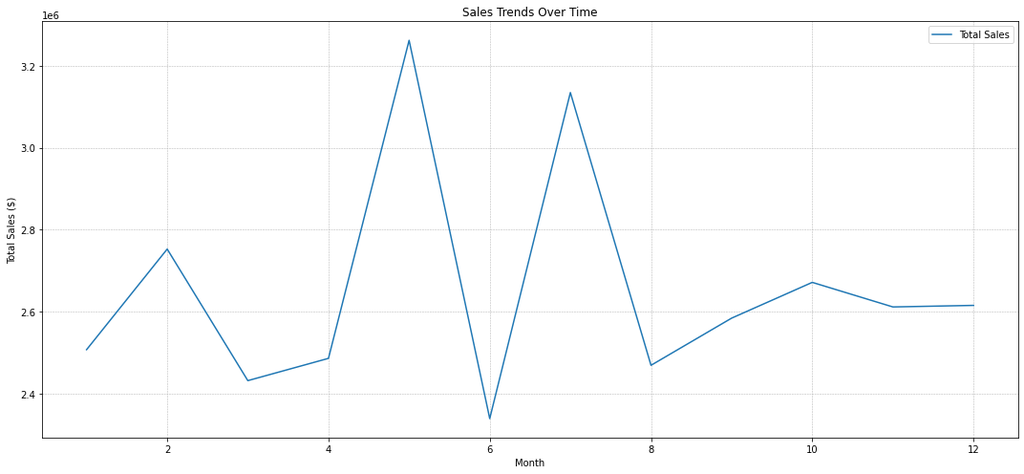

```python
# Year line charts of total sales by month
#2018
#2019
#2020
list=[y_2018, y_2019, y_2020]
for x in list:
    # Plotting the time series data
    plt.figure(figsize=(15, 7))
    plt.plot(x['month'], x['TotalSales'], label='Total Sales')
    plt.title("Sales Trends Over Time")
    plt.xlabel('Month')
    plt.ylabel('Total Sales ($)')
    plt.legend()
    plt.grid(True, which='both', linestyle='--', linewidth=0.5)
    plt.tight_layout()
    plt.show()
```

#### Immediate Insight

Total sales are the highest in the months of November and December. They are the lowest in late winter/early spring. The line charts show an large unpward trend in year 2018, less so in 2019. 2020 is volatile with no trend.

### Logistics Analysis

```python
# Convert dtypes
list=['ord_to_ship','delivery','shipping', 'shelf_time']
for x in list:
    df[x]=df[x].astype(str)
```

```python
df['ord_to_ship'] = df['ord_to_ship'].str.split(' ',expand=True)[0]
df['delivery'] = df['delivery'].str.split(' ',expand=True)[0]
df['shipping'] = df['shipping'].str.split(' ', expand=True)[0]
df['shelf_time'] = df['shelf_time'].str.split(' ', expand=True)[0]
```

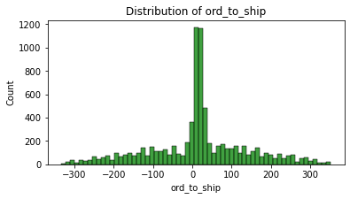

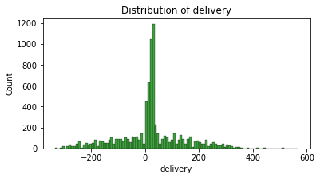

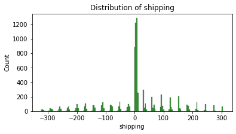

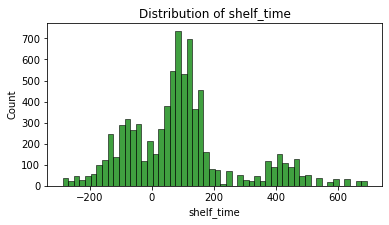

```python
# Distribution of logistics
list=['ord_to_ship','delivery','shipping','shelf_time']
for x in list:
    df[x]=df[x].astype(float)

for x in list:
    plt.figure(figsize=(6,3))
    sns.histplot(df[x], color="green" )
    plt.title("Distribution of "+x)
    plt.show()
```

```python
#Explore logistic features
log= df[['ord_to_ship','delivery','shipping', 'shelf_time']]
df.drop(product_time, axis=1, inplace=True)

#Explore cont variables
log.agg(['median','mean']).T
```

|  | median | mean |
| --- | --- | --- |
| ord_to_ship | 16.0 | 15.912401 |
| delivery | 24.0 | 20.274684 |
| shipping | 5.0 | 4.362283 |
| shelf_time | 85.0 | 92.396196 |

#### Immediate Insight

The logistic features are not valid because of the negative values that should not exist, however by looking at the histograms and measures of center you can see the days that occur most frequently.

### Order Quanity Analysis

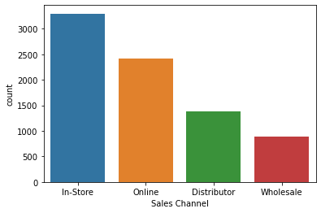

```python
#Orders by Sales Channel
sns.countplot(df['Sales Channel'])
plt.show()
```

```
Sales Channel
Distributor     6287
In-Store       14878
Online         10897
Wholesale       4100
Name: Order Quantity, dtype: int64
```

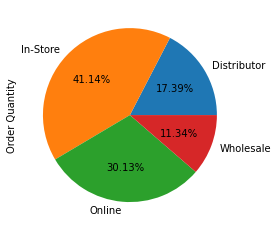

```python
# Sum of Order Quanities by Sales Channel
print(df.groupby('Sales Channel')['Order Quantity'].sum())

# % Breakdown of Order Quantity Sum by Sales Channel
df.groupby('Sales Channel')['Order Quantity'].sum().plot(title='', kind='pie', autopct='%0.2f%%')
plt.show()
```

```
WarehouseCode
WARE-MKL1006     3816
WARE-NBV1002     3101
WARE-NMK1003    11351
WARE-PUJ1005     6572
WARE-UHY1004     5765
WARE-XYS1001     5557
Name: Order Quantity, dtype: int64
```

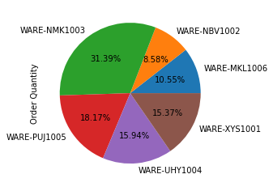

```python
# Order Quantity handled by each warehouse
print(df.groupby('WarehouseCode')['Order Quantity'].sum())
df.groupby('WarehouseCode')['Order Quantity'].sum().plot(title='', kind='pie', autopct='%0.2f%%')
plt.show()
```

### Profit Analysis

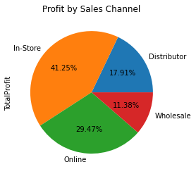

```python
# Sum of Total Profit by Sales Channel
df.groupby('Sales Channel')['TotalProfit'].sum().plot(title= 'Profit by Sales Channel', kind='pie',autopct='%0.2f%%')
plt.show()
```

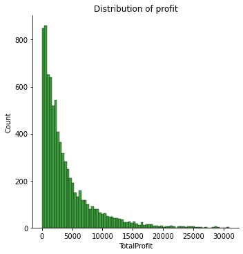

```
2398.5999999999995
```

```python
# Distribution of Total Profit per transaction
plt.figure(figsize=(6,3))
sns.displot(df['TotalProfit'], color="green" )
plt.title("Distribution of profit")
plt.show()

# Avg profit per transaction
print(df['TotalProfit'].median())
```

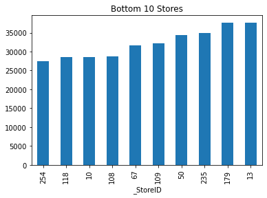

```
Lowest Gross: 27367.09
```

```python
# 10 Least profitables stores

df.groupby('_StoreID')['TotalProfit'].sum().sort_values().head(10).plot(title='Bottom 10 Stores', kind='bar')
plt.show()

# Lowest Grossing store
print('Lowest Gross:', df.groupby('_StoreID')['TotalProfit'].sum().min())
```

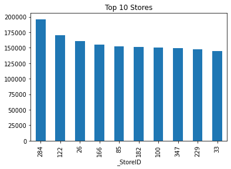

```
Highest Gross: 196050.82
```

```python
# 10 Most profitables stores

df.groupby('_StoreID')['TotalProfit'].sum().sort_values(ascending=False).head(10).plot(title='Top 10 Stores', kind='bar')
plt.show()

# Highest grossing store
print('Highest Gross:', df.groupby('_StoreID')['TotalProfit'].sum().max())
```

```python
#Avg sum profit across stores from 2018-2020

yyy=df['TotalProfit'].sum()
zzz=df['_StoreID'].nunique()
yyy/zzz
```

```
84127.13275204359
```

```python
# Discount used proportion for transactions
print(df['Discount Applied'].value_counts(normalize=True))
```

```
0.050    0.293831
0.075    0.250907
0.100    0.168439
0.150    0.120010
0.200    0.083344
0.400    0.043299
0.300    0.040170
Name: Discount Applied, dtype: float64
```